# W3cubDocs

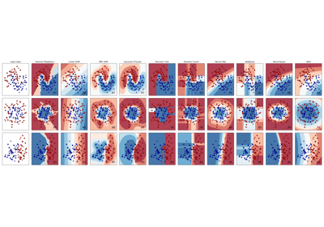

Classifier comparison

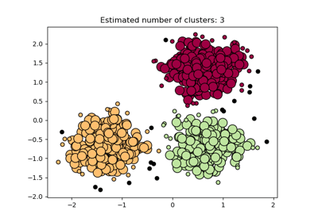

Demo of DBSCAN clustering algorithm

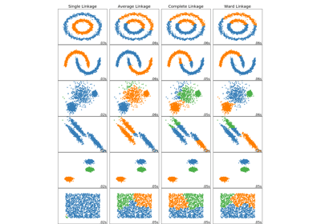

Comparing different hierarchical linkage methods on toy datasets

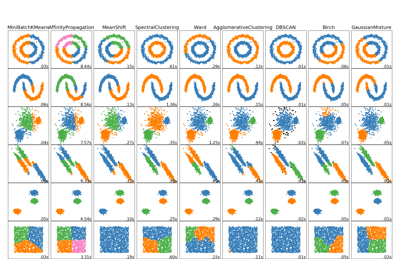

Comparing different clustering algorithms on toy datasets

[figure not shown]

Column Transformer with Mixed Types

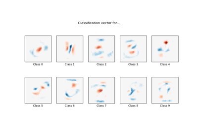

MNIST classfification using multinomial logistic + L1

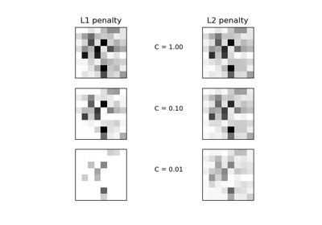

L1 Penalty and Sparsity in Logistic Regression

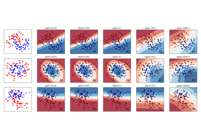

Varying regularization in Multi-layer Perceptron

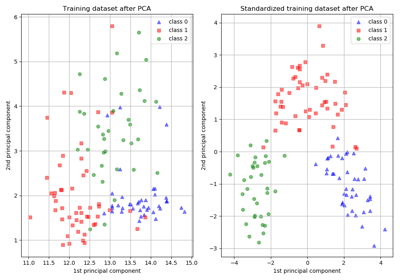

Importance of Feature Scaling

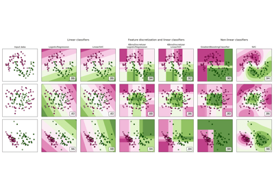

Feature discretization

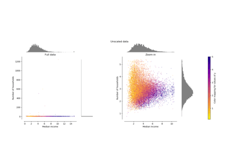

Compare the effect of different scalers on data with outliers

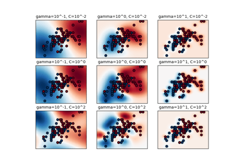

RBF SVM parameters